# 140.712 Advanced Data Science Final Project

Alison E. Turnbull

December 4, 2018

#### Motivation and Overview: Provide an overview of the project goals and the motivation for it. Consider that this will be read by people who did not see your project proposal.

In the United States, many people are treated in intensive care units (ICUs) in the final months of their lives. For some people, ICU care is appropriate and helpful. But many people with incurable diseases would prefer to be awake and at home with their families at the end of their lives, even if that means dying sooner. To ensure that patients and their families know about their options when they’re at high risk of dying the [**Choosing Wisely**](http://www.choosingwisely.org/) campaign made the following recommendation in 2014:

> [*“Don’t continue life support for patients at high risk for death or severely impaired functional recovery without offering patients and their families the alternative of care focused entirely on comfort.”*](http://www.choosingwisely.org/clinician-lists/critical-care-societies-collaborative-life-support-for-patients-at-high-risk-for-death-or-severely-impaired-functional-recovery/)

Unfortunately, widespread adoption of this recommendation in clinical practice has been difficult. Most doctors want to communicate clearly with the families of their critically ill patients, but many aren’t sure what to say or how to say it, in part because there isn’t much evidnce-based guidance on how to communicate effectively in this setting.

Last year I conducted a randomized trial (clinicaltrials.gov: NCT02721810) in the [Simulation Center at Johns Hopkins](https://www.hopkinsmedicine.org/simulation_center/index.html) to test whether prompting ICU doctors to think about long term prognosis would improve adhereance to the guideline. During the trial, 116 ICU doctors from around the U.S. provided data on their training and demographics (A), came to the Simulation Center and each reviewed the medical record of a single hypothetical ICU patient. Doctors in the control group (B1) were prompted to think about the pateint’s medical treatment plan. Doctors in the control group we prompted to think about both the medical treatment plan, and the pateint’s long-term prognosis (B2). The hypothetical patient was in his 80s, unlikely to survive his current illness, and unable to communicate. Each doctor then participated in a simulated family meeting with an actress playing the hypothetical patient’s daughter (C). These simulated meetings were video and audio recorded and then transcribed into de-identified written transcripts (E). The physicians and actors then provided feedback on the simulation (D), and two ICU physicians independently reviewed deidentified versions of the transcripts (F) and answered the question: *“Did this intensivist communicate that the patient may die as a result of his current illness despite treatment?”*

[figure not shown]

Trial procedures

I’m hopeful these transcripts can help us understand how ICU doctors talk to family members when they believe a patient is likely to die. It’s hard to find out what happens during these meetings in the real world, in part because doctors and families frequently disagree.

#### Related Work: Anything that inspired you, such as a paper, a web site, or something we discussed in class.

The trial was a follow-up to a [trial using online vignettes published in 2014](https://www.ncbi.nlm.nih.gov/pubmed/24584065).

I’ve always felt a little uneasy about the way recordings of ICU family meetings are usually analyzed in my field. Most investigators use grounded theory which involves humans reading transcripts and looking for patterns.

##### EXAMPLES

[The Language of Prognostication in Intensive Care Units](https://www.ncbi.nlm.nih.gov/pmc/articles/PMC2812635/)  
[Direct observation of prognosis communication in palliative care: a descriptive study](https://www.ncbi.nlm.nih.gov/pubmed/22652135)  
[Characterizing the Nature of Scan Results Discussions: Insights Into Why Patients Misunderstand Their Prognosis](https://www.ncbi.nlm.nih.gov/pubmed/28095172)

But humans aren’t great at recognizing complex patterns involving more than a few variables, so this seems like a task that machine learning techniques might shed new light on.

### Initial Questions: What questions are you trying to answer? How did these questions evolve over the course of the project? What new questions did you consider in the course of your analysis?

The two main questions I want to answer are: **1. Are there patterns in the way physicians in this study talked to family members during the simulated family meetings?** a. Are there textual features within the simulation transcripts that cluster together? If so, how can the clusters be described? b. Are there physician characteristics that correlate with clusters created by text features? c. Do clusters correlate with how actors or blinded physician colleagues interpreted the doctors in the study?

**2. Which textual features best predict whether the blinded physician colleagues thought prognosis for survival was disclosed?** a. Are there correlations between either MD characteristics and predicted probability of prognosis disclosure?

#### Data: What is the data source? Document the data import, wrangling, etc.

Because there are potential identifiers in the data, I am going to create a de-identified version for this analysis. This next chunk will not be evaluated, but it will show you where the data frame containing data on physician characteristics came from and how it was wrangled. I will then remove these data frames, leaving behind only the di-identified version for the rest of this analysis.

```r
## Loading in the study data which is contained in multiple dataframes connected by a shared unique identifier variable called "uid"
    load("X:/Moore Early Career Investigator Award/Aim 3/Study Data/Data shared with Di Chen/[20180312] dataset v5/20180313_SCIP data & codebook.RData")

## Loading data on location of home hospital and merging that information into the dataframe containing physician characteristics
    location<-read_csv("20180704_Participant hospital locations.csv")
    md<-merge(md, location, by="uid")

## Extracting variables relevant to this analysis
 ## The md dataframe contains physician characteristics
    md<-md %>%
        select(uid, age, gender, race, tx, religion_importance, icu_weeks, icu_type, train_med, train_sx, train_em, train_anes, hosp_ac_st_univ, baltimore, state)

 ## The pre_dta dataframe contains data the doctors self-reported before the simulation
    pre_dta<-pre_dta %>%
        select(uid, prognosis_survive, prognosis_mc, consult_palliative)

 #The post_dta dataframe contains data the doctors self-reported after the simulation
    post_dta<-post_dta %>%
        select(uid, disagreement_perceived, tracheotomy, withdraw_life_support)

 #The post_sp dataframe contains actor assessments of the simulation reported immediately afterward
    post_sp<-post_sp %>%
        select(uid, effort_to_help, effort_to_listen, effort_to_include, disagreement, sp)

 #The outcome dataframe contains assessments of the simulations provided by blinded colleague reviewers reading transcriptions
    outcome<-outcome %>%
        filter(assesser=="final") %>%
        select(uid, comfort, comfort_understandable, withdraw, death, death_word, prognosis, assesser)

## Merging all these data sources together
    dta<-Reduce(function(x, y) merge(x, y, by="uid"), list(md, pre_dta, post_dta, post_sp, outcome))

 ## Removing redundant dataframes and those with potentially identifying information
    rm(key, location, md, outcome, post_dta, post_sp, pre_dta)

    write_csv(dta, "140.712_Final_dta.csv")
```

Reading in sharable csv files  
Summary_measures.csv was created by [Gary Weissman, MD, MSHP](https://www.med.upenn.edu/apps/faculty/index.php/g353/p6504556) at UPenn. Thanks Gary!

```r
    dta<-read_csv("140.712_Final_dta.csv")
    sum_measures<-read_csv("summary_measures.csv")
        ## Renaming the unique identifier in this dataframe for merging purposes:
        sum_measures<-rename(sum_measures, uid=study_id)

    ## Here's data on how long each simulation went on.
    duration<-read_csv("20180810_Simulation_duration.csv")
    sum_measures<-merge(sum_measures, duration, by="uid")
```

Cleaning the summary measures and creating new variables

```r
    dta<-dta %>% arrange(uid)
    sum_measures<-sum_measures %>% arrange(uid)

sum_measures<-sum_measures %>%
    mutate(mins=signif(as.numeric(duration/60)), 3) %>%          ## Total duration of the simulation in minutes
    mutate(wrd_total=wrd_cnt_phys+wrd_cnt_prox) %>%              ## Total number of words spoken during simulation

    mutate(totalwrd_per_min=wrd_total/mins) %>%                  ## Total words per minute within simulation
    mutate(physwrd_per_min=wrd_cnt_phys/mins) %>%                ## Physician words per minute
    mutate(proxwrd_per_min=wrd_cnt_prox/mins) %>%                ## Proxy words per minute
    mutate(wrdratio_physprox=wrd_cnt_phys/wrd_cnt_prox) %>%      ## Ratio of physician:proxy words

    mutate(uttratio_physprox=uttr_cnt_phys/uttr_cnt_prox) %>%    ## Ratio of physician:proxy utterances

    mutate(i_my_cnt=pron_i_cnt+pron_my_cnt) %>%                  ## Count of the number of the pronouns "I" and "my"
    mutate(you_your_cnt=pron_you_cnt+pron_your_cnt) %>%          ## Count of the number of the pronouns "you" and "your"
    mutate(she_hers=pron_she_cnt+pron_her_cnt+pron_hers_cnt) %>% ## Count of the number of the pronouns "she" and "her" and "hers"
    mutate(he_his=pron_he_cnt+pron_his_cnt) %>%                  ## Count of the number of the pronouns "he" and "his"
    mutate(i_my_prop=signif(i_my_cnt/wrd_total, 3)) %>%          ## Proportion of all words that are "I" or "my"
    mutate(you_your_prop=signif(you_your_cnt/wrd_total, 3)) %>%  ## Proportion of all words that are "you" or "yours"
    mutate(she_her_prop=signif(she_hers/wrd_total, 3)) %>%       ## Proportion of all words that are "her" or "hers"
    mutate(he_his_prop=signif(he_his/wrd_total, 3))  %>%         ## Proportion of all words that are "he" or "his"

    mutate(phys_verb_prop=signif(phys_verb_cnt/wrd_cnt_phys, 3)) %>%     ## Proportion of physician words that are verbs
    mutate(phys_noun_prop=signif(phys_noun_cnt/wrd_cnt_phys, 3)) %>%     ## Proportion of physician words that are nouns
    mutate(phys_adj_prop=signif(phys_adjective_cnt/wrd_cnt_phys, 3)) %>% ## Proportion of physician words that are adjectives
    mutate(phys_adv_prop=signif(phys_adverb_cnt/wrd_cnt_phys, 3))%>%     ## Proportion of physician words that are adverbs

    mutate(voa_prop=signif(voa_cnt/wrd_total, 3)) %>%                    ## Proportion of words in the VOA lexicon
    mutate(nlm_prop=signif(nlm_minus_voa_cnt/wrd_total, 3)) %>%          ## Proportion of words in the nlm but not not VOA lexicon
    mutate(death_word=dta$death_word)                                    ## Also, there's a variable currently in the "dta" dataframe which indicates whether the physician used the words "death", "die", or "dying."

    ## Keeping the cleaned features
    sum_measures<-sum_measures %>%
        select(uid, wrd_total, wrd_cnt_phys, wrd_cnt_prox, wrdratio_physprox, mins, totalwrd_per_min,
              physwrd_per_min, proxwrd_per_min, uttratio_physprox, mean_wrds_uttr_phys, median_wrds_uttr_phys,
              mean_wrds_uttr_prox, median_wrds_uttr_prox,
              voa_prop, nlm_prop, fk_score, gf_score, pattern_sent,
              wwbp_to_past, wwbp_to_present, wwbp_to_future,
              i_my_prop, you_your_prop, she_her_prop, he_his_prop,
              phys_verb_prop, phys_noun_prop, phys_adj_prop, phys_adv_prop, death_word)
```

##### Exploratory Data Analysis: What visualizations did you use to look at your data in different ways? What are the different statistical methods you considered? Justify the decisions you made, and show any major changes to your ideas. How did you reach these conclusions? You should use this section to motivate the statistical analyses that you decided to use in the next section.

First exploring the physician characteristics using density plots

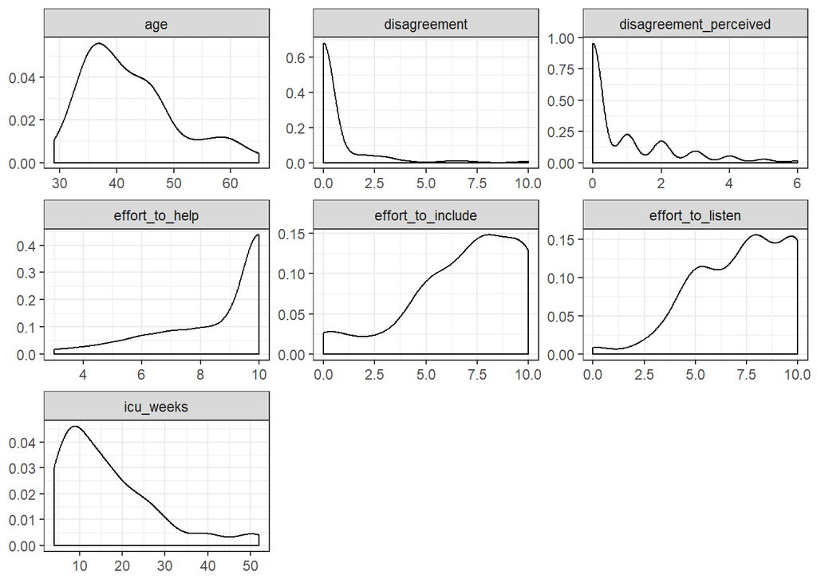

```r
dta_long_con<-dta %>%
    select(uid, age, icu_weeks, disagreement, disagreement_perceived, effort_to_help, effort_to_listen, effort_to_include) %>%
    gather(key=feature, value = value, -uid)

dta_long_con %>%
    ggplot(aes(value)) +
    geom_density(alpha=0.5)+
    facet_wrap( ~feature, scales='free', ncol=3) +
    labs(x = NULL, y = NULL) +
    theme_bw()
```

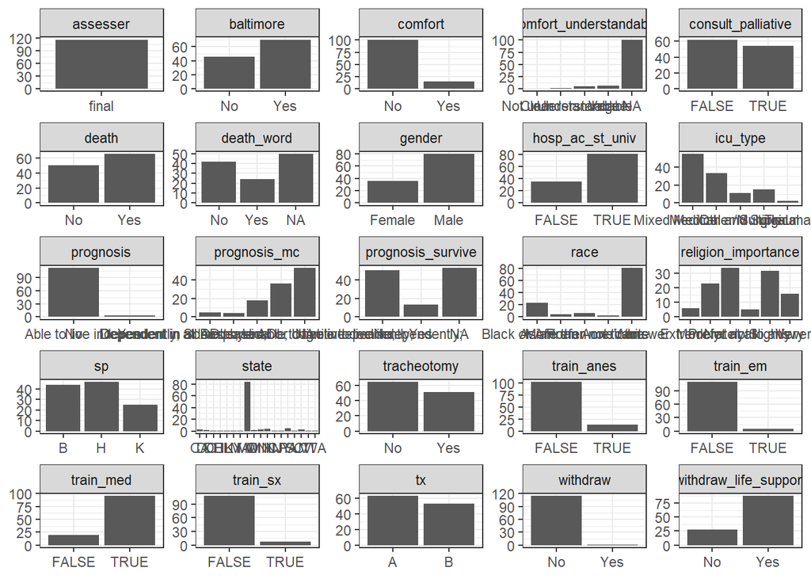

```r
dta_long_cat<-dta %>%
    select(-c(age, icu_weeks, disagreement, disagreement_perceived, effort_to_help, effort_to_listen, effort_to_include)) %>%
    gather(key=feature, value = value, -uid)

dta_long_cat %>%
    ggplot(aes(value)) +
    geom_bar() +
    facet_wrap( ~feature, scales='free', ncol=5) +
    labs(x = NULL, y = NULL) +
    theme_bw()
```

Looking at the relationships between MD characteristics, their case management, and their colleagues’ assessment of whether prognosis for survival was disclosed

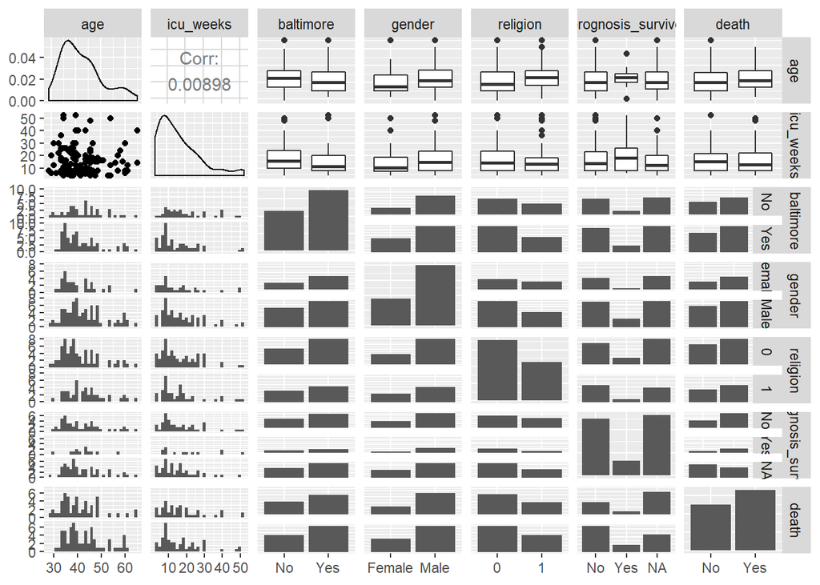

```r
library("GGally")

dta %>%
    mutate(religion=ifelse(religion_importance=="Extremely" | religion_importance=="Very" | religion_importance=="Moderately", 1, 0)) %>%
    mutate(religion=factor(religion)) %>%
    select(age, icu_weeks, baltimore, gender, religion, prognosis_survive, death) %>%
    ggpairs()
```

Relationships between how actors perceived the physicians and whether the physicians reported conflict during the simulation, colored by disclosure

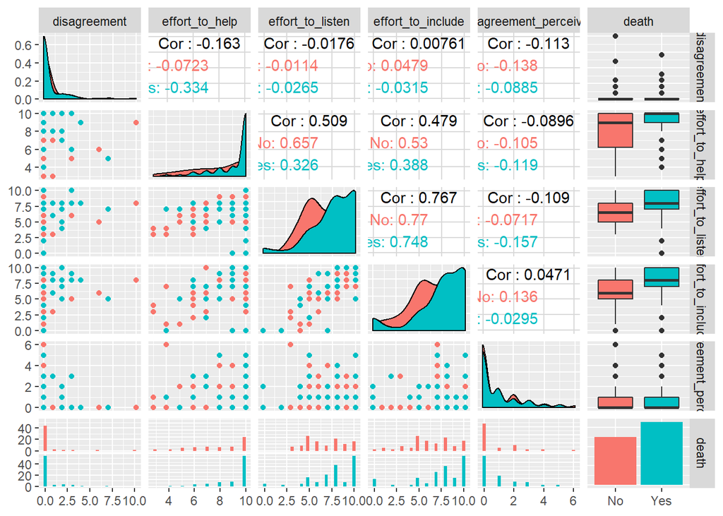

```r
dta %>%
    select(disagreement, effort_to_help, effort_to_listen, effort_to_include, disagreement_perceived, death) %>%
    ggpairs(aes(color=factor(death)))
```

Relationships between how actors perceived the physicians and whether the physicians reported conflict during the simulation, colored by actor

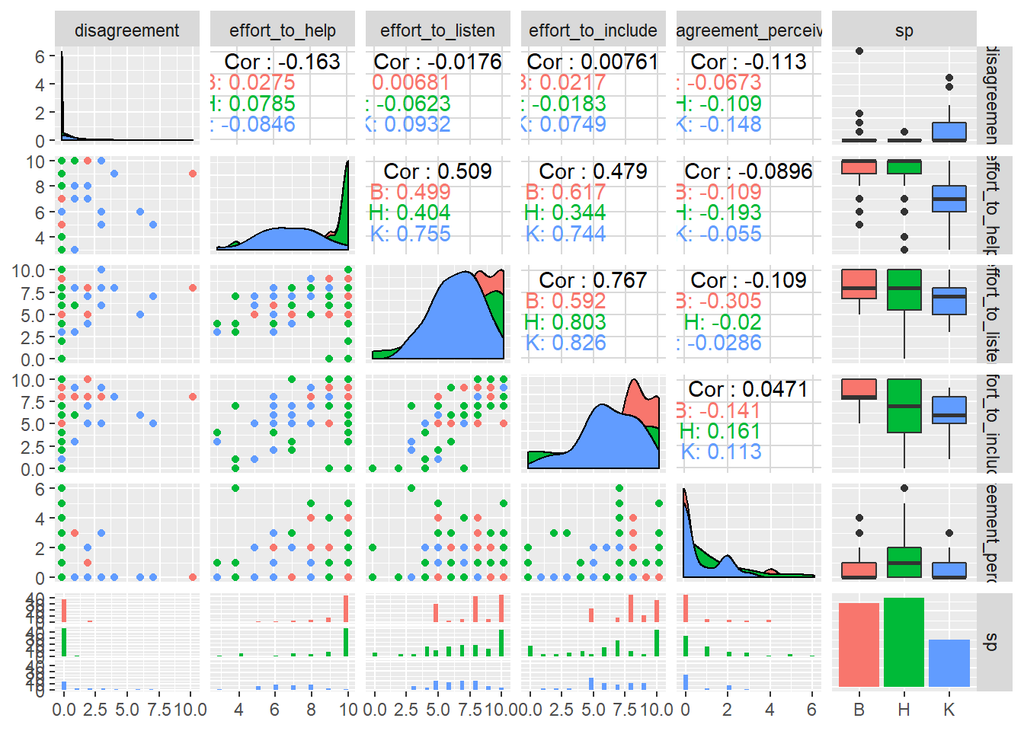

```r
dta %>%
    select(disagreement, effort_to_help, effort_to_listen, effort_to_include, disagreement_perceived, sp) %>%
    ggpairs(aes(color=factor(sp)))
```

Now exploring the transcript characteristics

[figure not shown]

```r
transcripts_long<-sum_measures %>%
    gather(key=feature, value = value, -uid)

transcripts_long %>%
    ggplot(aes(value)) +
        geom_density()+
        facet_wrap( ~feature, scales='free', ncol=6) +
        labs(x = NULL, y = NULL) +
        theme_bw()
```

Exploring transcript features by whether colleagues thought prognosis was disclosed

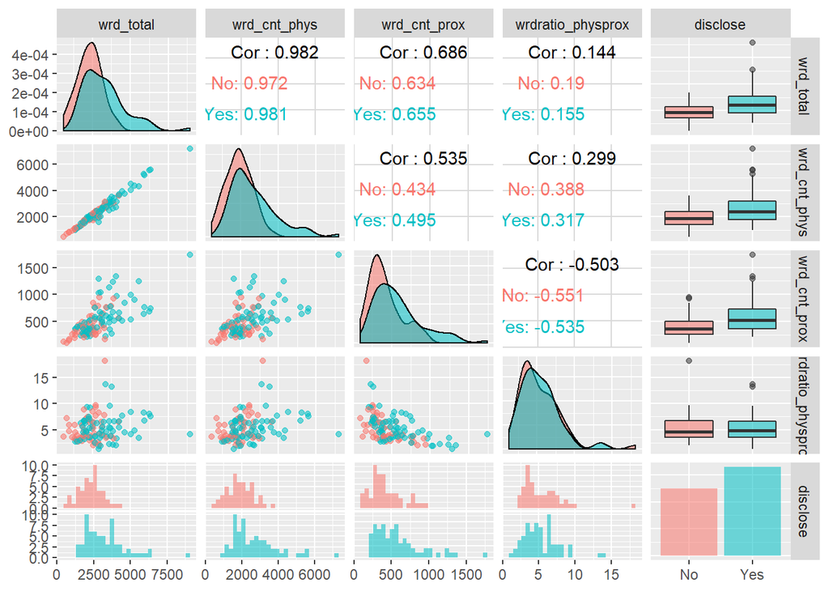

```r
sum_measures %>%
    arrange(uid) %>%
    mutate(disclose = dta$death) %>%
    select(wrd_total, wrd_cnt_phys, wrd_cnt_prox, wrdratio_physprox, disclose) %>%
    ggpairs(aes(color=factor(disclose), alpha=0.5))
```

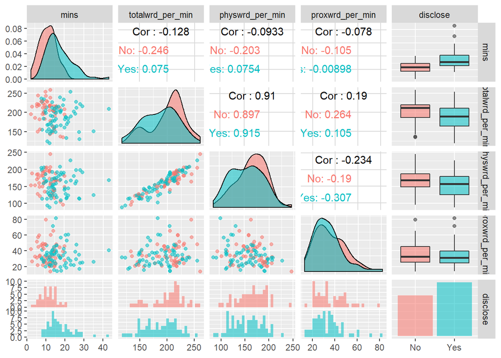

```r
sum_measures %>%
    arrange(uid) %>%
    mutate(disclose = dta$death) %>%
    select(mins, totalwrd_per_min, physwrd_per_min, proxwrd_per_min, disclose) %>%
    ggpairs(aes(color=factor(disclose), alpha=0.5))
```

Wow. So, meetings were a little longer, and there are definitely fewer words per minute spoken when prognosis was disclosed.

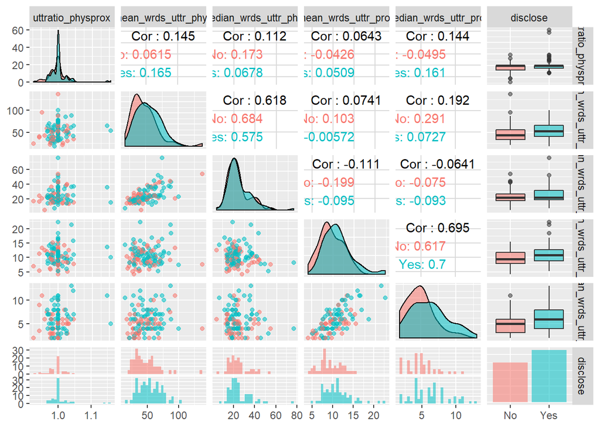

```r
sum_measures %>%
    arrange(uid) %>%
    mutate(disclose = dta$death) %>%
    select(uttratio_physprox, mean_wrds_uttr_phys, median_wrds_uttr_phys, mean_wrds_uttr_prox, median_wrds_uttr_prox, disclose) %>%
    ggpairs(aes(color=factor(disclose), alpha=0.5))
```

Huh, looks like physicians always speak in paragraphs of about the same length, but proxies spoke a little longer if prognosis was disclosed. There are some physician:proxy utterance ratio outliers that are interesting too.

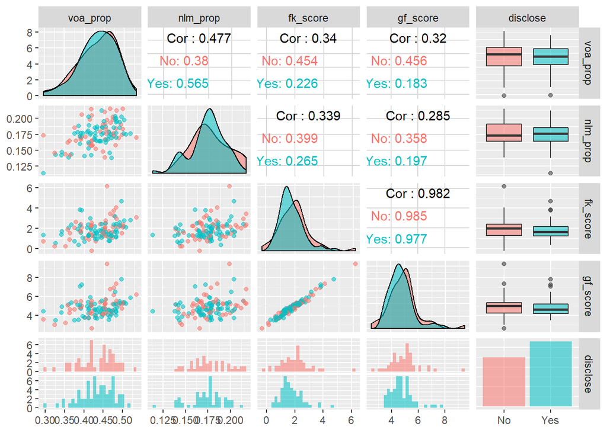

```r
sum_measures %>%
    arrange(uid) %>%
    mutate(disclose = dta$death) %>%
    select(voa_prop, nlm_prop, fk_score, gf_score, disclose) %>%
    ggpairs(aes(color=factor(disclose), alpha=0.5))
```

What’s interseting is how little variability there is here. Disclosure does NOT appear to be correlated with how simple or complex physician language is.

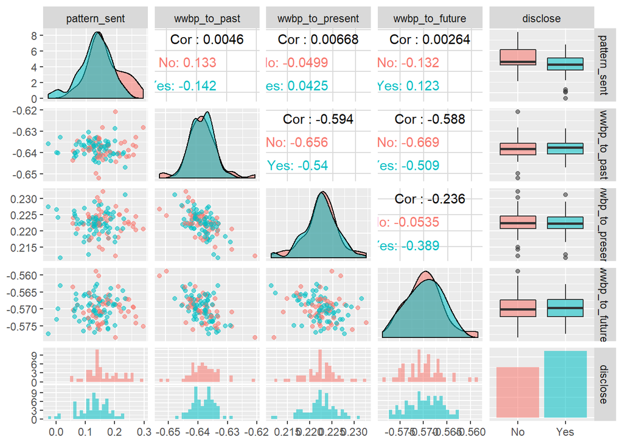

```r
sum_measures %>%
    arrange(uid) %>%
    mutate(disclose = dta$death) %>%
    select(pattern_sent, wwbp_to_past, wwbp_to_present, wwbp_to_future, disclose) %>%
    ggpairs(aes(color=factor(disclose), alpha=0.5))
```

Really nothing of obvious interest here.

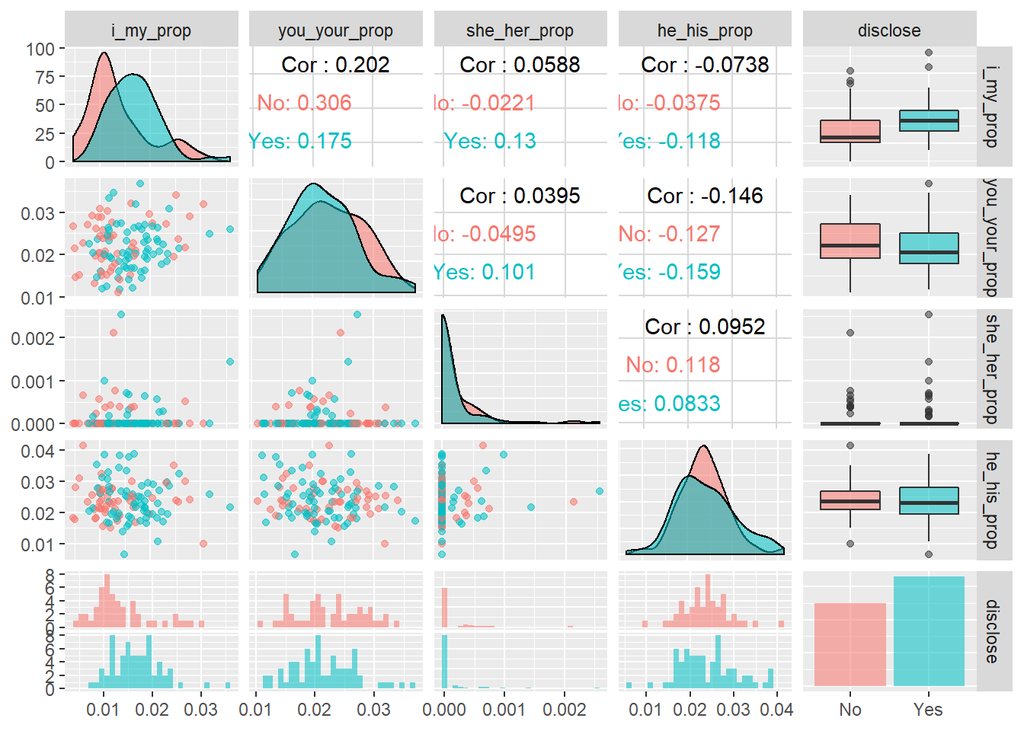

```r
sum_measures %>%
    arrange(uid) %>%
    mutate(disclose = dta$death) %>%
    select(i_my_prop, you_your_prop, she_her_prop, he_his_prop, disclose) %>%
    ggpairs(aes(color=factor(disclose), alpha=0.5))
```

Huh. There’s an interesting shift toward the words “i” and “my” when prognosis is disclosed.

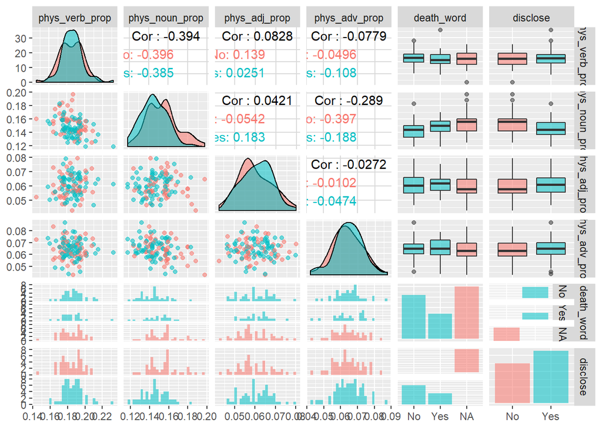

```r
sum_measures %>%
    arrange(uid) %>%
    mutate(disclose = dta$death) %>%
    select(phys_verb_prop, phys_noun_prop, phys_adj_prop, phys_adv_prop, death_word, disclose) %>%
    ggpairs(aes(color=factor(disclose), alpha=0.5))
```

I’m not seeing anything very interesting here.

Ok, so after looking at all those plots there just aren’t any strong, obvious relationships. Probably that’s because none exist, but maybe they involve complex interactions. I don’t have any hypotheses about how many clusters there may be, so an agglomerative (“bottom up”) approach seems most appropriate.

##### Data Analysis: What statistical or computational method did you apply and why? What others did you consider?

1. Are there patterns in the way physicians in this study talked to family members during the simulated family meetings?** a. Are there textual features within the simulation transcripts that cluster together? If so, how can the clusters be described?

Step 1: computing the distance between each transcript using two different distances - euclidean and manhattan

```r
library("rafalib")

    matrix_measures<-sum_measures %>%
        select(-c(uid))

    matrix_measures[which(is.na(matrix_measures$death_word)), "death_word"]    <-"No"
    sum_measures$death_word<-factor(sum_measures$death_word)

    ## Distance matrices using two measures
    d_euclid = dist(matrix_measures, method="euclidean")
    d_manhat = dist(matrix_measures, method="manhattan")
```

Now lets visualize the results using dendograms

```r
    ## Hierarchical clustering
    hc_euclid<-hclust(d_euclid)
    hc_manhat<-hclust(d_manhat)

    ## Add labels
    hc_euclid$labels<-dta$uid
    hc_manhat$labels<-dta$uid

    ## First lets see how the trial arms disperse across the clusters
    myplclust(hc_euclid, lab.col = as.numeric(as.factor(dta$tx)), cex=0.5)
```

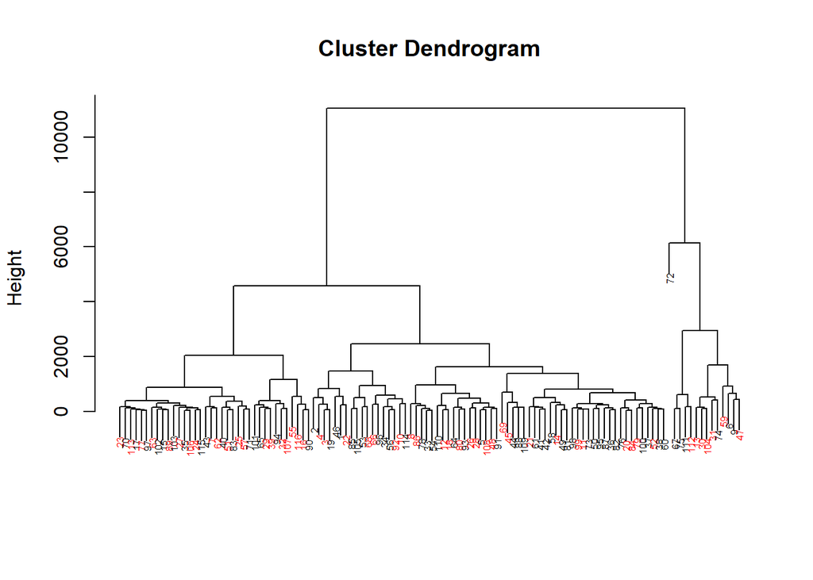

```r
    myplclust(hc_manhat, lab.col = as.numeric(as.factor(dta$tx)), cex=0.5)
```

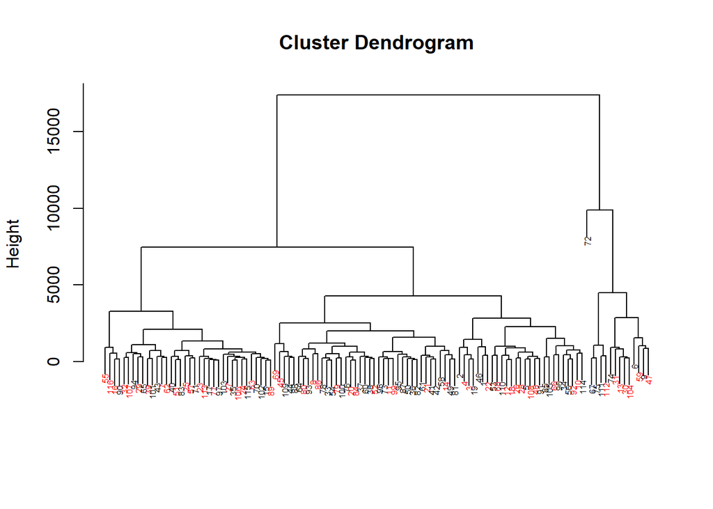

Nope, nothing related to trial arm but 3 clear clusters with a serious outlier.

```r
    ## And now looking at whether there's a pattern by whether colleagues thought prognosis was disclosed
    myplclust(hc_euclid, lab.col = as.numeric(as.factor(dta$death)), cex=0.5)
```

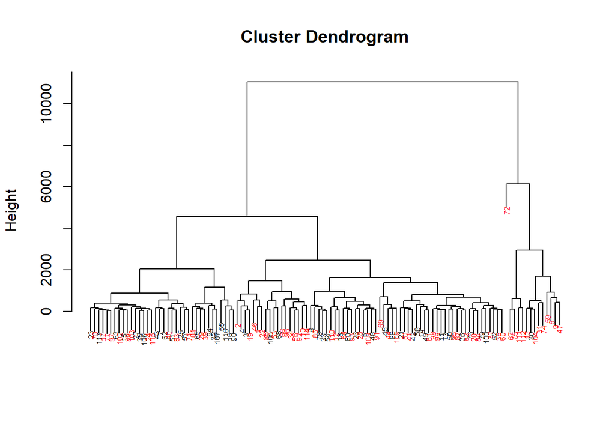

```r
    myplclust(hc_manhat, lab.col = as.numeric(as.factor(dta$death)), cex=0.5)
```

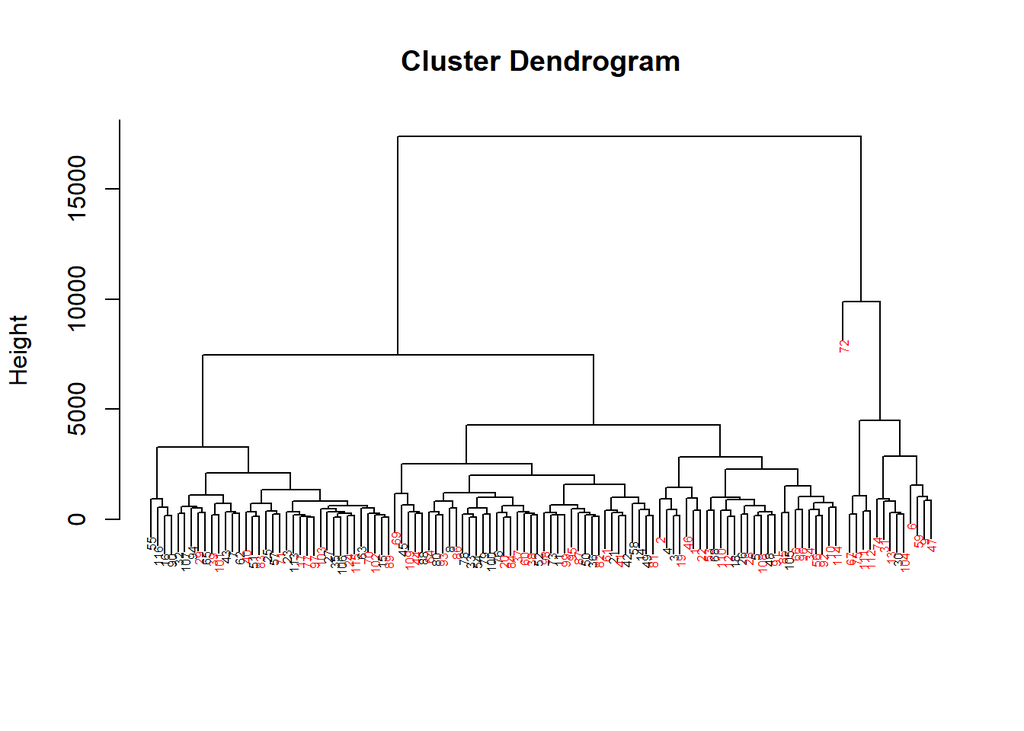

Huh, so, the cluster on the far right seems to be almost entirely red - interesting. I guess the good news is that euclidian vs manhattan distance doesn’t seem to matter. There looks like there are 3 pretty clear clusters and #72 is a real outlier.

```r
    ## Creating the clusters by cutting the tree
    eu_clusters<-cutree(hc_euclid, h=4000)

    ## Attaching these cluster designations to the dataframe of transcript characteristics
    sum_measures$cluster<-eu_clusters
    sum_measures[which(sum_measures$uid==72), "cluster"]<-2  #I'm moving this outlier into cluster 2 so we only have 3 groups.
```

```r
    library("tableone")
    CreateTableOne(strata="cluster", data=sum_measures)
```

```
##                                    Stratified by cluster
##                                     1                2
##   n                                      66               14
##   uid (mean (sd))                     56.32 (33.00)    57.86 (36.61)
##   wrd_total (mean (sd))             2970.85 (550.87) 5427.64 (1256.21)
##   wrd_cnt_phys (mean (sd))          2413.48 (482.61) 4614.79 (1029.26)
##   wrd_cnt_prox (mean (sd))           557.36 (278.60)  812.86 (334.08)
##   wrdratio_physprox (mean (sd))        5.49 (3.05)      6.16 (1.73)
##   mins (mean (sd))                    15.65 (3.81)     25.85 (6.66)
##   totalwrd_per_min (mean (sd))       194.06 (29.27)   212.71 (24.74)
##   physwrd_per_min (mean (sd))        158.52 (31.24)   181.40 (24.57)
##   proxwrd_per_min (mean (sd))         35.54 (15.47)    31.32 (8.18)
##   uttratio_physprox (mean (sd))        1.00 (0.02)      1.00 (0.01)
##   mean_wrds_uttr_phys (mean (sd))     53.18 (21.22)    59.25 (18.50)
##   median_wrds_uttr_phys (mean (sd))   26.39 (11.70)    27.21 (9.50)
##   mean_wrds_uttr_prox (mean (sd))     10.81 (3.40)      9.90 (3.08)
##   median_wrds_uttr_prox (mean (sd))    5.82 (2.64)      4.46 (2.24)
##   voa_prop (mean (sd))                 0.43 (0.05)      0.46 (0.03)
##   nlm_prop (mean (sd))                 0.17 (0.02)      0.17 (0.01)
##   fk_score (mean (sd))                 1.83 (0.98)      1.70 (0.97)
##   gf_score (mean (sd))                 4.85 (1.04)      4.67 (1.02)
##   pattern_sent (mean (sd))             0.15 (0.05)      0.14 (0.04)
##   wwbp_to_past (mean (sd))            -0.64 (0.00)     -0.64 (0.00)
##   wwbp_to_present (mean (sd))          0.22 (0.00)      0.22 (0.00)
##   wwbp_to_future (mean (sd))          -0.57 (0.00)     -0.57 (0.00)
##   i_my_prop (mean (sd))                0.02 (0.01)      0.02 (0.00)
##   you_your_prop (mean (sd))            0.02 (0.01)      0.02 (0.00)
##   she_her_prop (mean (sd))             0.00 (0.00)      0.00 (0.00)
##   he_his_prop (mean (sd))              0.02 (0.01)      0.02 (0.01)
##   phys_verb_prop (mean (sd))           0.19 (0.01)      0.18 (0.01)
##   phys_noun_prop (mean (sd))           0.15 (0.01)      0.15 (0.02)
##   phys_adj_prop (mean (sd))            0.06 (0.01)      0.06 (0.01)
##   phys_adv_prop (mean (sd))            0.06 (0.01)      0.06 (0.01)
##   death_word = Yes (%)                   12 (31.6)         8 (61.5)
##   cluster (mean (sd))                  1.00 (0.00)      2.00 (0.00)
##                                    Stratified by cluster
##                                     3                p      test
##   n                                      36
##   uid (mean (sd))                     62.75 (34.17)   0.655
##   wrd_total (mean (sd))             1666.17 (397.72) <0.001
```

[output cut: 15 more lines]

```
##   gf_score (mean (sd))                 4.87 (0.90)    0.797
##   pattern_sent (mean (sd))             0.13 (0.07)    0.468
##   wwbp_to_past (mean (sd))            -0.64 (0.00)    0.848
##   wwbp_to_present (mean (sd))          0.22 (0.00)    0.865
##   wwbp_to_future (mean (sd))          -0.57 (0.00)    0.816
##   i_my_prop (mean (sd))                0.01 (0.01)    0.753
##   you_your_prop (mean (sd))            0.02 (0.01)    0.979
##   she_her_prop (mean (sd))             0.00 (0.00)    0.436
##   he_his_prop (mean (sd))              0.03 (0.01)    0.001
##   phys_verb_prop (mean (sd))           0.19 (0.02)    0.246
##   phys_noun_prop (mean (sd))           0.15 (0.02)    0.137
##   phys_adj_prop (mean (sd))            0.06 (0.01)    0.122
##   phys_adv_prop (mean (sd))            0.06 (0.01)    0.609
##   death_word = Yes (%)                    4 (26.7)    0.103
##   cluster (mean (sd))                  3.00 (0.00)   <0.001
```

Cool! Cluster 2 is really interesting - these 14 simulations were almost twice as long, had nearly twice as many words, and more physician words per minute but no more proxy words per minute. There were also more words per physician utterance, and they were about twice as likely to say the one of the big D words (death, die, or dying). Differentiating between clusters 1 and 3 is a little harder, but cluster 3 were VERY short meetings in general. I wonder if they cluster 3 is the physicians who essentially just went in the room and gave a quick update.

Moving on to question 1b. Are there physician characteristics that correlate with clusters created by text features?

```r
## Attaching these cluster designations to the dataframe of physician characteristics
    dta$cluster<-eu_clusters
    dta[which(sum_measures$uid==72), "cluster"]<-2  #I'm moving this outlier into cluster 2 so we only have 3 groups.

    MDTable<-dta %>%
        mutate(Race = fct_collapse(race,
                                   white = "White",
                                   asian = "Asian",
                                   other = c("Black or African American", "More than one race", "Prefer not to answer"))) %>%
        mutate(Religion_importance = fct_collapse(religion_importance,
                                   high = c("Extremely", "Very"),
                                   moderate = "Moderately",
                                   low = c("Slightly", "Not at all"),
                                   Missing = "Prefer not to answer")) %>%
        select(cluster, age, gender, Race, Religion_importance, icu_weeks, icu_type, train_med, train_sx, train_em, train_anes, hosp_ac_st_univ,
               baltimore, prognosis_survive, prognosis_mc, consult_palliative, disagreement_perceived, tracheotomy, withdraw_life_support)

        CreateTableOne(strata = "cluster", data=MDTable)
```

```
##                                                                     Stratified by cluster
##                                                                      1
##   n                                                                     66
##   cluster (mean (sd))                                                 1.00 (0.00)
##   age (mean (sd))                                                    42.12 (8.12)
##   gender = Male (%)                                                     43 (65.2)
##   Race (%)
##      asian                                                              11 (16.7)
##      other                                                               4 ( 6.1)
##      white                                                              51 (77.3)
##   Religion_importance (%)
##      high                                                               14 (21.2)
##      moderate                                                           17 (25.8)
##      low                                                                35 (53.0)
##      Missing                                                             0 ( 0.0)
##   icu_weeks (mean (sd))                                              16.60 (12.32)
##   icu_type (%)
##      Medical                                                            32 (48.5)
##      Mixed Medical and Surgical                                         20 (30.3)
##      Other/Multiple                                                      6 ( 9.1)
##      Surgical                                                            7 (10.6)
##      Trauma                                                              1 ( 1.5)
##   train_med = TRUE (%)                                                  56 (84.8)
##   train_sx = TRUE (%)                                                    4 ( 6.1)
##   train_em = TRUE (%)                                                    2 ( 3.0)
##   train_anes = TRUE (%)                                                  7 (10.6)
##   hosp_ac_st_univ = TRUE (%)                                            47 (71.2)
##   baltimore = Yes (%)                                                   38 (57.6)
##   prognosis_survive = Yes (%)                                            8 (20.0)
##   prognosis_mc (%)
##      Able to live independently; Some physical or cognitive decline;     3 ( 7.5)
##      Deceased;                                                           4 (10.0)
##      Dependent in all ADLs; Unable to live independently;               12 (30.0)
##      Dependent in at least one ADL; Unable to live independently;       21 (52.5)
##   consult_palliative = TRUE (%)                                         31 (47.0)
##   disagreement_perceived (mean (sd))                                  0.95 (1.48)
##   tracheotomy = Yes (%)                                                 27 (40.9)
##   withdraw_life_support = Yes (%)                                       50 (75.8)
##                                                                     Stratified by cluster
##                                                                      2
```

[output cut: 135 more lines]

```
##   train_sx = TRUE (%)
##   train_em = TRUE (%)
##   train_anes = TRUE (%)
##   hosp_ac_st_univ = TRUE (%)
##   baltimore = Yes (%)
##   prognosis_survive = Yes (%)
##   prognosis_mc (%)
##      Able to live independently; Some physical or cognitive decline;
##      Deceased;
##      Dependent in all ADLs; Unable to live independently;
##      Dependent in at least one ADL; Unable to live independently;
##   consult_palliative = TRUE (%)
##   disagreement_perceived (mean (sd))
##   tracheotomy = Yes (%)
##   withdraw_life_support = Yes (%)
```

What’s most striking here is how FEW physician characteristics differ by cluster. Group 2 looks more secular, and they don’t perceive any conflict in the room, but otherwise, there’s nothing notable about them. Group 3 stands out for having a higher percentage of non-white and non-asian physicians, but otherwise they’re very hard to tell from group 1.

Finally, question c. Do clusters correlate with how actors or blinded physician colleagues interpreted the doctors in the study?

```r
    SPTable<-dta %>%
        mutate(Race = fct_collapse(race,
                                   white = "White",
                                   asian = "Asian",
                                   other = c("Black or African American", "More than one race", "Prefer not to answer"))) %>%
        mutate(Religion_importance = fct_collapse(religion_importance,
                                   high = c("Extremely", "Very"),
                                   moderate = "Moderately",
                                   low = c("Slightly", "Not at all"),
                                   Missing = "Prefer not to answer")) %>%
        select(cluster, sp, comfort, disagreement, effort_to_help, effort_to_listen, effort_to_include, death)

        CreateTableOne(strata = "cluster", data=SPTable)
```

```
##                                Stratified by cluster
##                                 1            2            3
##   n                               66           14           36
##   cluster (mean (sd))           1.00 (0.00)  2.00 (0.00)  3.00 (0.00)
##   sp (%)
##      B                            30 (45.5)     3 (21.4)    11 (30.6)
##      H                            21 (31.8)     5 (35.7)    21 (58.3)
##      K                            15 (22.7)     6 (42.9)     4 (11.1)
##   comfort = Yes (%)                7 (10.6)     4 (28.6)     4 (11.1)
##   disagreement (mean (sd))      0.45 (1.31)  0.71 (1.33)  0.39 (1.69)
##   effort_to_help (mean (sd))    8.83 (1.69)  9.14 (1.35)  8.19 (2.27)
##   effort_to_listen (mean (sd))  8.05 (1.99)  7.93 (1.38)  5.72 (2.44)
##   effort_to_include (mean (sd)) 7.85 (2.08)  7.86 (1.88)  5.08 (3.19)
##   death = Yes (%)                 38 (57.6)    13 (92.9)    15 (41.7)
##                                Stratified by cluster
##                                 p      test
##   n
##   cluster (mean (sd))           <0.001
##   sp (%)                         0.022
##      B
##      H
##      K
##   comfort = Yes (%)              0.177
##   disagreement (mean (sd))       0.771
##   effort_to_help (mean (sd))     0.155
##   effort_to_listen (mean (sd))  <0.001
##   effort_to_include (mean (sd)) <0.001
##   death = Yes (%)                0.005
```

Fascinating. So, standardized patient “H” is over-represented in cluster 3, and “K” is disproportionately in cluster 2.  
Cluster 2 was way more likely to offer the option of care focused on comfort, and nearly everyone disclosed death.

*Moving on to my second question* **2. Which textual features best predict whether the blinded physician colleagues thought prognosis for survival was disclosed?** a. Are there correlations between either MD characteristics and predicted probability of prognosis disclosure?

Looking at measures of variable importance for bagged trees.

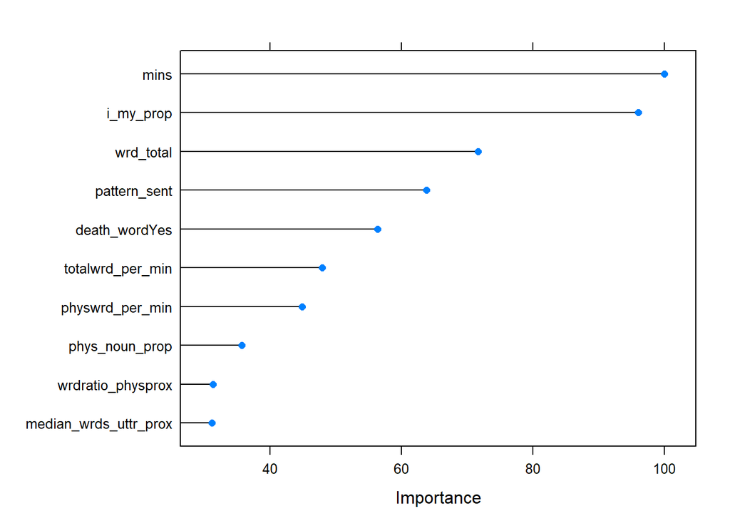

```r
library("rpart")
library("caret")
        control <- trainControl(method="repeatedcv", number=5, repeats=3)  ## 5 folds in cross validation, repeated 3 times
        seed <- 12072018
        metric <- "Accuracy"

        ## Adding the outcome variable to this dataframe
        sum_measures<-sum_measures %>%
                        arrange(uid) %>%
                        mutate(disclose = as.factor(dta$death))

        sum_measures[which(is.na(sum_measures$death_word)), "death_word"]    <-"No"

        ## Creating a collection of bagged trees to classify transcripts by whether the colleagus thought prognosis was disclosed.
        fit_bagging<- train(disclose ~., data=select(sum_measures, -uid, -cluster, -wrd_cnt_phys, -wrd_cnt_prox),
                            method="treebag", metric=metric, trControl=control)

        bagImp<-varImp(fit_bagging, scale = FALSE)
        bagImp_scaled<-varImp(fit_bagging, scale = TRUE)
        plot(bagImp_scaled, top = 10)
```

The predictive nature of the words “I” and “my” are fascinating to me. I can definitely come up with some hypotheses about what role those pronouns are playing. Lets see how well these results hold up with different classification techniques.

Looking at measures of variable importance for boosted trees.

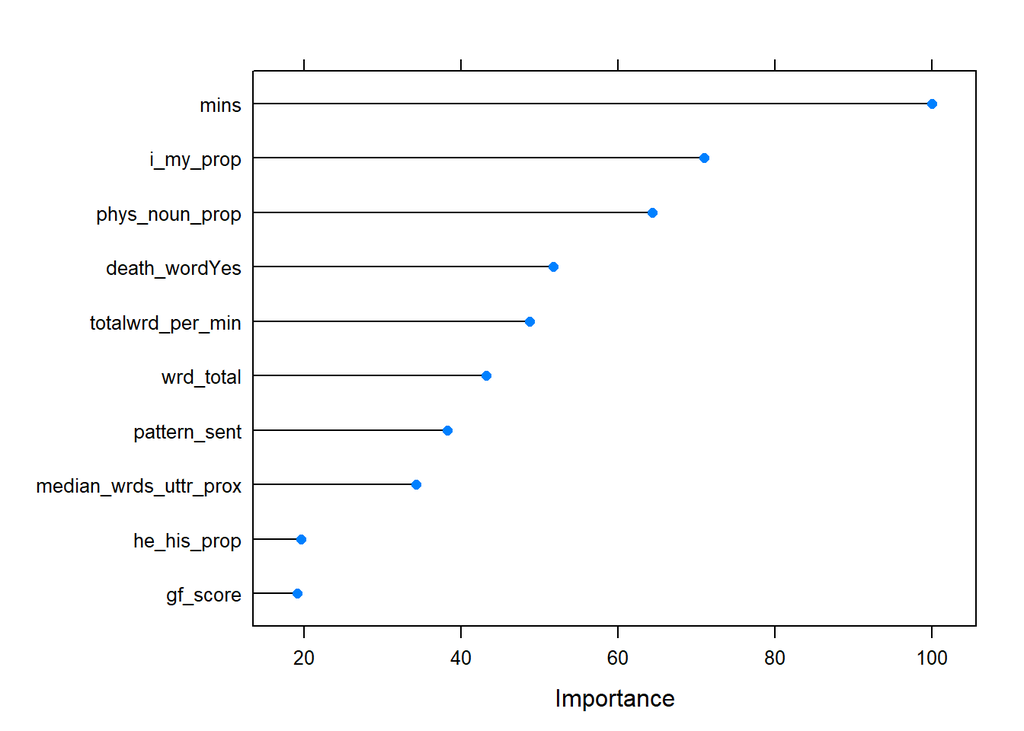

```r
library("gbm")
fit_boost<- train(disclose ~., data=select(sum_measures, -uid, -cluster, -wrd_cnt_phys, -wrd_cnt_prox),
                            method="gbm", metric=metric, trControl=control, verbose=FALSE)

        boostImp<-varImp(fit_boost, scale = FALSE)
        boostImp_scaled<-varImp(fit_boost, scale = TRUE)
        plot(boostImp_scaled, top = 10)
```

The top 2 remain strong with numbers 3 - 7 moving around a bit but the line-up remains similar.

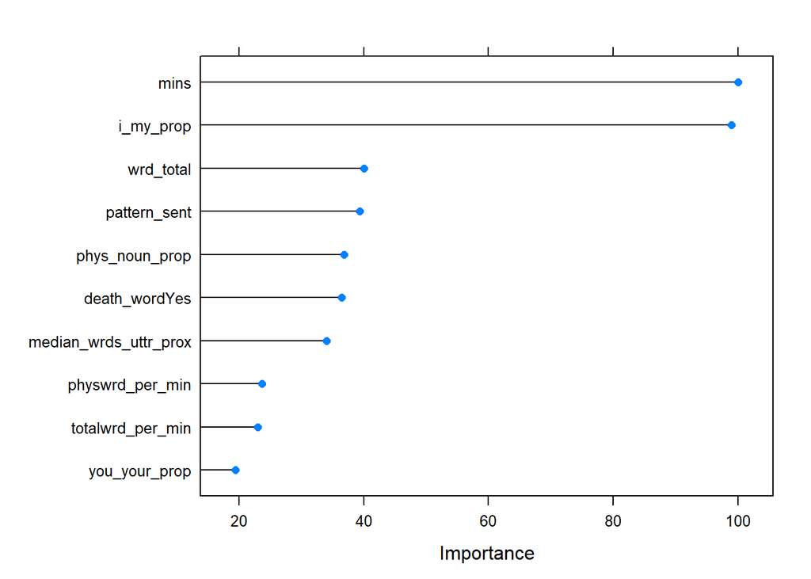

```r
    fit_rf<- train(disclose ~., data=select(sum_measures, -uid, -cluster, -wrd_cnt_phys, -wrd_cnt_prox),
                            method="rf", metric=metric, trControl=control)
        rfImp<-varImp(fit_rf, scale = FALSE)
        rfImp_scaled<-varImp(fit_rf, scale = TRUE)
        plot(rfImp_scaled, top = 10)
```

There are a bunch of other fun ways to look at the results of random forests I’d like to explore.

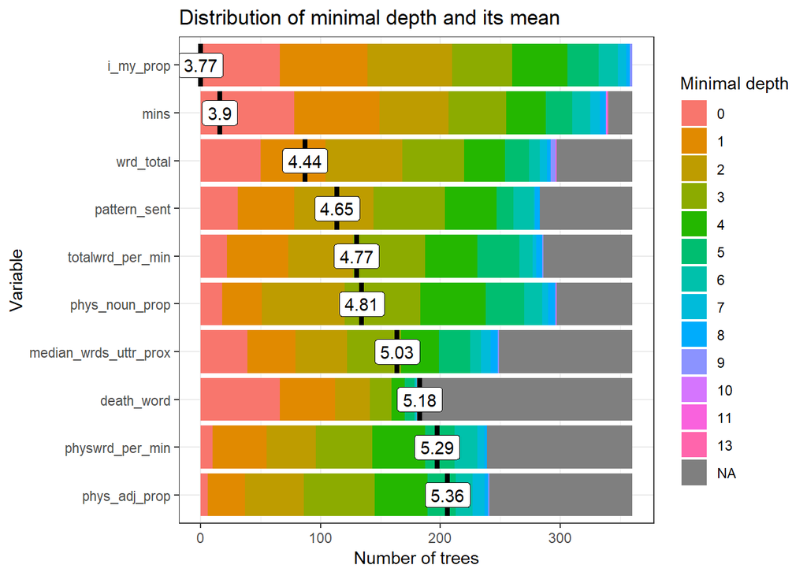

```r
library("randomForest")
library("randomForestExplainer")
    set.seed(20181207)
    rf2<- randomForest(disclose ~., data=select(sum_measures, -uid, -cluster, -wrd_cnt_phys, -wrd_cnt_prox), localImp=TRUE)
    min_depth_frame<-min_depth_distribution(rf2)
    plot_min_depth_distribution(min_depth_frame, mean_sample = "all_trees", k=10)
```

Very cool, so, again, the “I/my” pronouns remain strong. Sentiment pattern ranked a little more highly.

Lets look at a couple more measures for these variables.

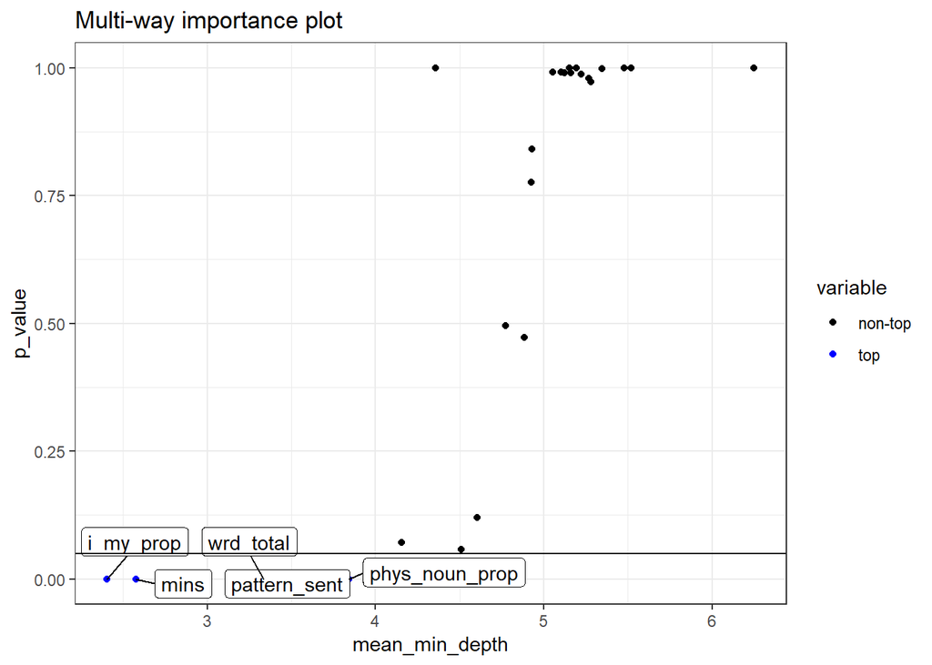

```r
        importance_frame <- measure_importance(rf2)
        plot2<-plot_multi_way_importance(importance_frame, x_measure = "mean_min_depth", y_measure="p_value", no_of_labels = 5)
        plot2+
            geom_hline(aes(yintercept=0.05))
```

This is a nice example of why any given p-value cut-off is far from the whole story.

Lets take a quick peek at interactions

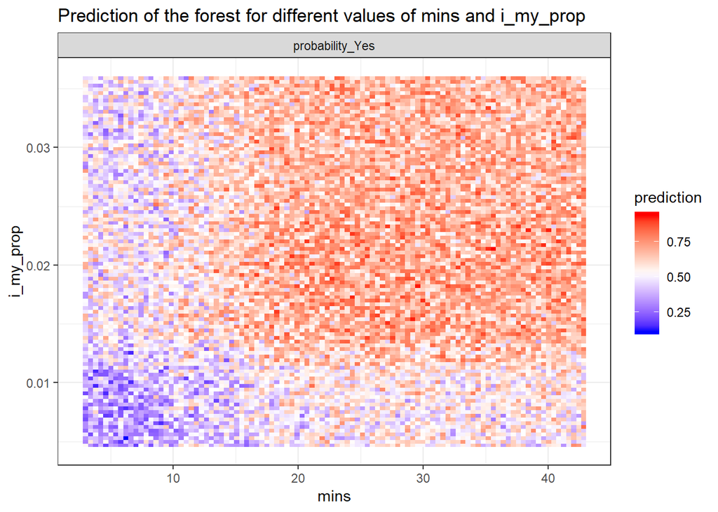

```r
    plot_predict_interaction(rf2, data=select(sum_measures, -uid, -cluster, -wrd_cnt_phys, -wrd_cnt_prox), "mins", "i_my_prop")
```

So, if the MD’s in the room for more than 15 minutes and more than 1% of their words are either “I” or “my”, that’s a really good sign.

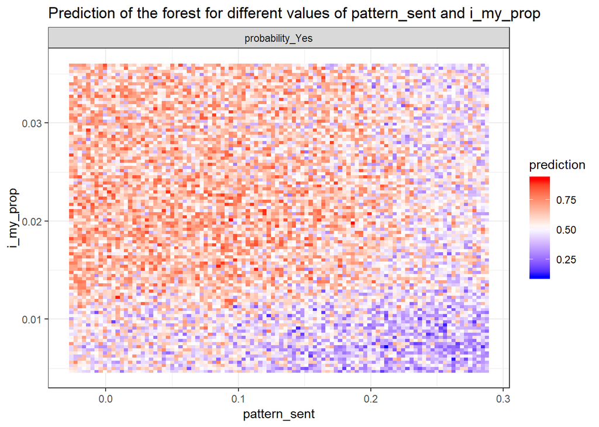

```r
    plot_predict_interaction(rf2, data=select(sum_measures, -uid, -cluster, -wrd_cnt_phys, -wrd_cnt_prox), "pattern_sent", "i_my_prop")
```

##### Narrative and Summary:

*What did you learn about the data?* In general, the vast majority of these textual features do not differ much across the physicains, are not strongly correlated with which arm of the trial physicains were randomized to, or with whether they chose to disclose prognosis. There does appear to be a group of about 14 doctors (group 2) with a distinctly different approach who meet with families for longer, dominate the conversation, didn’t perceive any conflict, and almost universally disclosed prognosis. Whether there’s truly a difference between groups 1 and 3 is less clear.

When trying to predict whether colleagues will categorize a meeting as including disclosure of prognosis, the two things that are probably most fruitful to focus on are duration and the proportion of the physicains words that were either “I” or “my”. Understanding why physicians used the words I/my more frequently when they were going to disclose prognosis requires more follow-up study to understand but I have a hypothesis which I’ll try to demonstrateusing samples of langauge on the study website.

*How did you answer the questions?* I used agglomerative hierarchical clustering to look for patterns in how physicains spoke to the simulated patients. I created aggregated decision trees (bagging, boosting, and random forests) to classify transcripts as disclosing or not disclosing prognosis to the patient’s family and then looked at measures of variable importance to get a sense of which textual features are best for discriminating between these groups.

*How can you justify your answers?* I’m not sure what you mean by this question. I’m trying hard not to overstate.

*What are the limitations of the analyses?* There are so many! To start with, I only had 116 samples and many of them were really random. I’d also LOVE to have a validation sample to help evaluate my classifiers and see if these same clustering patterns show up. Finally, I’d like to learn more about topic models and tidy text. But, time’s up, assignment is due.